# Titan Medical: the Road to Making the Name a Reality

## Summary

- Titan Medical is a pre-revenue corporation that is planning to launch its Minimally Invasive Surgery (MIS) Robot: The SPORT™ Surgical System
- Titan has favorable market conditions as the medical robotics industry is estimated to rapidly grow at a CAGR of 22%
- The MIS robotic surgery space is dominated by Intuitive Surgical’s da Vinci®. However, SPORT’s price tag is half of da Vinci’s, and it is smaller and portable, giving it a distinct competitive advantage
- Using a data-driven approach incorporating market factors, we estimated SPORT’s 15 year cumulative sales to be 1965 units

## Introduction

Titan Medical (TSE:TMD) operates in the medical robotics surgery space. In 2017, it plans to submit 510k and CE Mark applications for the SPORT Surgical System (Single Port Orifice Robotic Technology), which is a surgeon-controlled single-incision robotic platform incorporating a 3D high definition vision system accompanied by an ergonomic and effective surgeon workstation. This portable machine is designed to perform computer assisted robotic surgery. SPORT is expected to be priced less than $1M USD, which is about half the price of da Vinci, the robotic surgical system that currently holds a monopoly in this space in US and Europe.

Given that Titan Medical is pre-revenue, much uncertainty has surrounded its potential market opportunity. Here, RNFC outlines what Titan’s sales could look like over a 15-year timeframe. We have used an analytical, data-driven approach to estimate unit sales over this forecast.

## Background

### Robotic Surgery Industry

The global medical robot industry is forecasted to grow by 22.2% CAGR to $11.4B in 2020. This growth is driven by increased technologic adoption by healthcare facilities as well as the need to cut down on healthcare costs. Robots are becoming more precise, and patients often view healthcare facilities that have robots as technologically advanced. In fact, in the United States, having a medical robot at a hospital is a marketing tactic as patients often perceive it as an indicator of surgical quality. Surgeons operate in a similar way, causing healthcare facilities to purchase medical robots for talent acquisition purposes. For many small and mid-sized healthcare facilities, existing medical robots may come with a price tag that is too high to be affordable.

“Medical Robots Market Worth 11.4 Billion USD by 2020.” [Markets and Markets](http://www.marketsandmarkets.com/PressReleases/medical-robotic-systems.asp)

“Is da Vinci Robotic Surgery a Revolution or a Ripoff?” [Healthline](http://www.healthline.com/health-news/is-da-vinci-robotic-surgery-revolution-or-ripoff-021215#4)

“When a Small Hospital Wants a Surgical Robot.” [Advisory Board](https://www.advisory.com/daily-briefing/2014/04/22/when-a-small-hospital-wants-a-surgical-robot)

### The Minimally Invasive Robotic Surgery Landscape

#### Minimally Invasive Surgery

Minimally invasive surgery (MIS), in contrast to open surgery, is performed by making multiple small incisions through the skin. A thin, tube-like endoscopic camera is passed through one of the incisions, and a magnified view of the surgical area is displayed onto a monitor in the operating room. MIS surgeries are traditionally performed by hand, with the surgeon using a variety of different laparoscopic instruments through the incisions.

#### Intuitive’s da Vinci® Surgical System

Intuitive Surgical (NASDAQ: ISRG) is a medical robotics company that operates out of Sunnyvale, California, USA, with a market capitalization of $24B (June 2016). It commercialized the da Vinci Surgical System in 2000, which is a stationary robot that performs MIS procedures. It features three surgical arms that hold medical instruments, and a fourth arm for an endoscopic camera. The surgeon controls the machine from a console, which provides a 3D image of the procedure. Since its launch, Intuitive Surgical has dominated the MIS robotic space: there is an installed base of 3660 units world-wide. The price tag for its Si version is around $2M (all dollar figures are quoted in USD). Although widely adopted, the da Vinci has been criticized for its cost as well as concerns about performance.

“Robot Surgery Market Set to Change” [The Financial Times](http://www.ft.com/cms/s/0/f13a18be-e1cb-11e4-bb7f-00144feab7de.html#axzz4CJw0s0vL)

“Is da Vinci Robotic Surgery a Revolution or a Ripoff?” [Healthline](http://www.healthline.com/health-news/is-da-vinci-robotic-surgery-revolution-or-ripoff-021215#4)

“da Vinci Robot Allegedly Marketed to Less-Skilled Doctors?” [Lawyers and Settlements](https://www.lawyersandsettlements.com/articles/da-Vinci-robot/davinci-lawsuit-robot-2-18655.html?utm_expid=3607522-13.Y4u1ixZNSt6o8v_5N8VGVA.0&utm_referrer=https%3A%2F%2Fen.wikipedia.org%2F#.UXbJQytVTeI)

“da Vinci Robot Lawsuit.” [Surgical Watch](http://surgicalwatch.com/davinci-robot/lawsuit/)

#### Titan’s SPORT™ Surgical System

Titan began operations in 2008 in Toronto, Canada. Unlike da Vinci, the Titan SPORT Surgical System performs MIS procedures using a single incision, and has only one arm. Unique advantages of SPORT are that it is small and transportable. It would also cost healthcare facilities half the price of a da Vinci at an estimated price tag of $1M. Both machines have similar surgical capabilities, however, SPORT specializes in simple, high frequency procedures whereas da Vinci focuses on complex, low frequency procedures. Titan is currently in the process of commercializing this product, as they are undergoing their Human Factors and Usability Trials. They plan to file for FDA approval in the second half 2017, and are anticipated to begin deliveries around late 2017 or early 2018.

## SPORT’s Market Potential

Pre-revenue companies are often challenging to value, largely due to the difficulty of forecasting sales. As there are no historical numbers to reference, there can be a lot of uncertainty regarding market adoption of a new product. With the given information on the market, landscape, and players, we attempted to use a robust, data-driven approach to get an accurate estimation of SPORT’s market potential. We began by estimating market size, and then translating market size into year by year projections of units sold. Data was aggregated primarily from the following sources for this analysis: Center of Medicare and Medicaid Services (CMS), American Hospital Directory (AHD), Intuitive’s annual/quarterly reports, and Intuitive’s list of da Vinci surgeons.

### Estimating Market Size

We considered three different market segments: US hospitals, US ambulatory surgery centers (ASCs), and hospitals in Europe. These markets are the immediate addressable markets for Titan as they are pursuing FDA approval and CE mark.

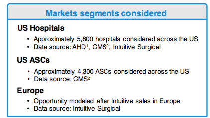

**Figure 1:** *Market Segments*

#### US Hospitals

We used probabilistic record linkage to merge four databases. Using the location of each hospital, we were able to get regional average income and regional population. Ninety percent of our database accurately matched through record linkage, with the remaining manually matched or imputed. Our consolidated database had a list of all US hospitals (5661 total) with 23 associated fields:

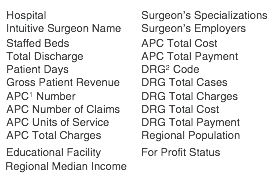

1. APC = Ambulatory Payment Classification (Classification for out-patient hospital procedures)
2. DRG = Diagnostic Related Group (Classification for in-patient hospital procedures)

We then determined which hospitals had a da Vinci machine, using the list of Intuitive surgeons’ employers. We created several financial ratios from the data and identified a number of relevant factors using a logistic regression. The logistic regression model used “having a da Vinci machine” (0 or 1) as the dependent variable and the various factors and financial ratios as the independent variables. We developed a Receiver Operating Characteristic (ROC) to test the quality of our logistic regression. The Area Under the Curve (AUC) was 0.93 out of 1.00, indicating a very good model. We then adjusted our factors to account for SPORT’s capabilities (e.g., focus on higher volume procedures) and price (e.g., financial ratios were modified to account for the difference in price between a da Vinci machine and a SPORT machine), and used the coefficients from the logistic regression model to estimate the probability of a hospital purchasing a SPORT machine. The sum of the probabilities from all hospitals is the expected market size. Results are summarized below:

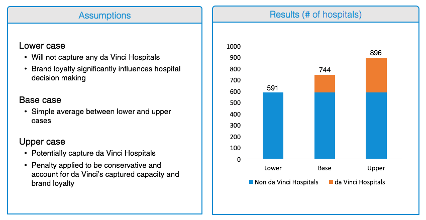

**Figure 2:** *US Hospital Results*

#### US ASCs

We then looked into ASCs. Although ASCs have a lower budget than hospitals, and very few have a da Vinci machine, ASCs can be a great target for SPORT considering SPORT’s economical advantage. We used CMS data on 4300 ASCs, and to be conservative, we filtered out ASCs that did not meet a minimum laparoscopic surgery volume of 230 procedures/year (which is the average number of procedures/year for a da Vinci machine) to justify the purchase of a SPORT. With the remaining 1700 ASCs we used our calculated hospital-equivalent performance metrics for these ASCs. We matched the ASC’s to the hospital prediction probabilities by their performance metrics using the k-Nearest Neighbors algorithm. This gave us a list of ASC’s and their estimated probability of purchasing a SPORT machine. The total market size for ASCs was 181 ASCs.

#### European Hospitals

The only international segment we considered was Europe, which was done because Titan is currently seeking CE Mark approval. For the European market we did not have complete datasets comparable to those available in the US. We thus used da Vinci’s European sales figures as a proxy. Da Vinci’s European sales as a percent of US sales are on average 26%. We applied this number to SPORT’s hospital market size to get the market potential of 193 hospitals for Europe.

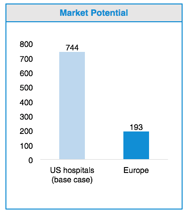

**Figure 3:** *European Hospitals Results*

The total potential market size (N) across all three segments for Titan is 1118 healthcare facilities. Since the databases for healthcare facilities includes 2014 data, this is the market size in year 2014. Although the medical robotics market is growing rapidly, part of this growth stems from diffusion of products in the market. In order to remain conservative, we assumed a long-term annual 2% growth on the market size, in line with USA and European GDP growth. Thus, we assumed that the market potential value N will grow at 2% year over year when projecting unit sales.

### Sales Projections

In this analysis, Year 1 is defined as the first year of sales post regulatory approval.

The estimates from the previous section represented total market potential for SPORT units. However, these sales would not occur instantly. Thus, we projected year by year sales for Titan. The following is a summary of the sales channels we considered

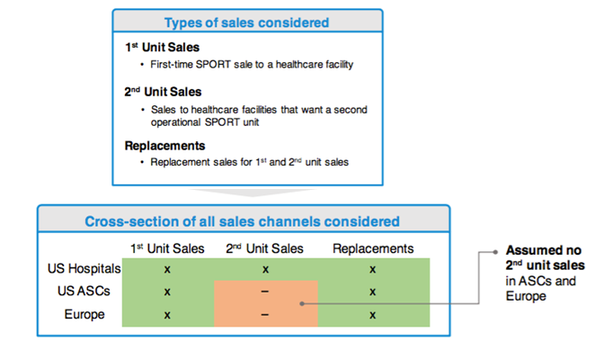

**Figure 4:** *Sales Channels Considered*

We used a Bass Model to estimate market diffusion. The Bass model is used to project adoption of new products, and incorporates three parameters: market size, $N$, (generated from the hospital analysis above); a coefficient of adoption, $p$ (representing those who purchase the product through direct sales efforts); and a coefficient of initiation, $q$ (representing those whose purchase decisions are strongly influenced by the purchase decisions of others). Our core assumption was that SPORT’s diffusion would follow the same pattern as da Vinci since they are similar products. The $p$ and $q$ coefficients were fitted to da Vinci historical sales, and we used the $N$ values for each of the sales channels from the market potential analysis.

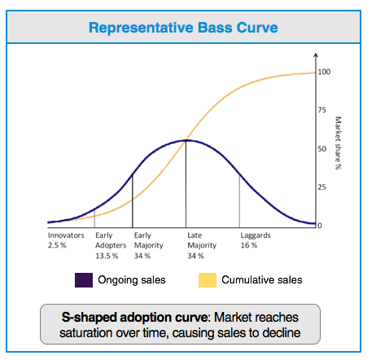

**Figure 5:** *Sample Bass Model*

#### First Unit Sales

We started by projecting 1<sup>st</sup> unit sales for all three market segments using the Bass model. The results of our 15-year bass model projections are summarized below:

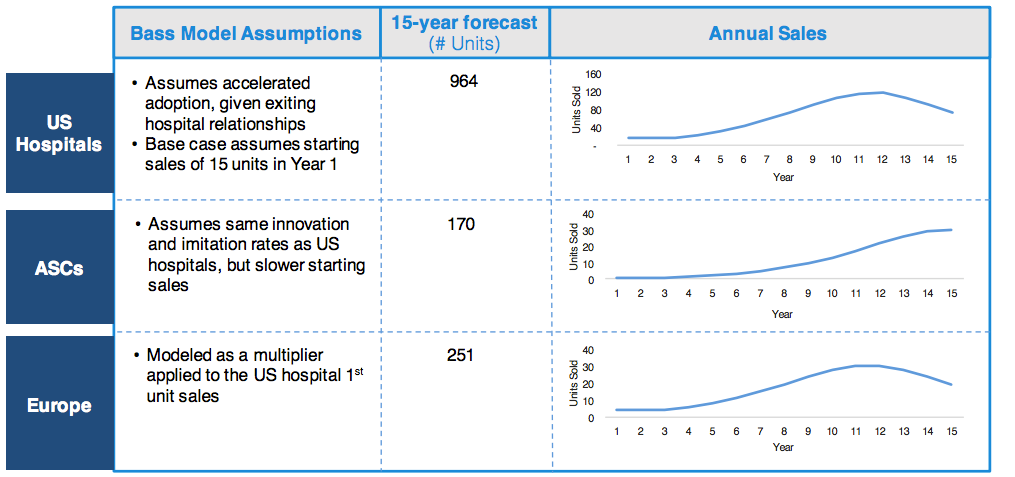

**Figure 6:** *First Unit Sales Results*

#### Second Unit Sales

Some healthcare facilities that purchase a da Vinci machine also purchase a second or third operating unit. Therefore, we assumed that this would also be the case for SPORT. We used our logistic regression model to estimate the market potential for second units. To remain conservative, we assumed that a facility would not purchase more than two operating units, and that only US Hospitals would be candidates for purchasing a second unit. To quantify how many hospitals would purchase a second unit, we adjusted procedure volume for each hospital by subtracting the number of procedures based on SPORT’s capacity from the total number of laparoscopic procedures done at that hospital. We generated forecasts for the probability of purchase of a second, given that the hospital had already purchased a unit, using the logistic regression model. We combined these estimates with the probabilities of purchasing a first unit to find the probability of purchasing a second unit. The sum of the probabilities across all hospitals was the expected second unit market size, which was treated as the market potential when forecasting total sales. We then applied the Bass model to generate year over year projections. To remain conservative, we assumed that 2<sup>nd</sup> unit purchases would only occur two years after SPORT’s commercialization. The year by year sales of 2<sup>nd</sup> unit purchases are summarized below:

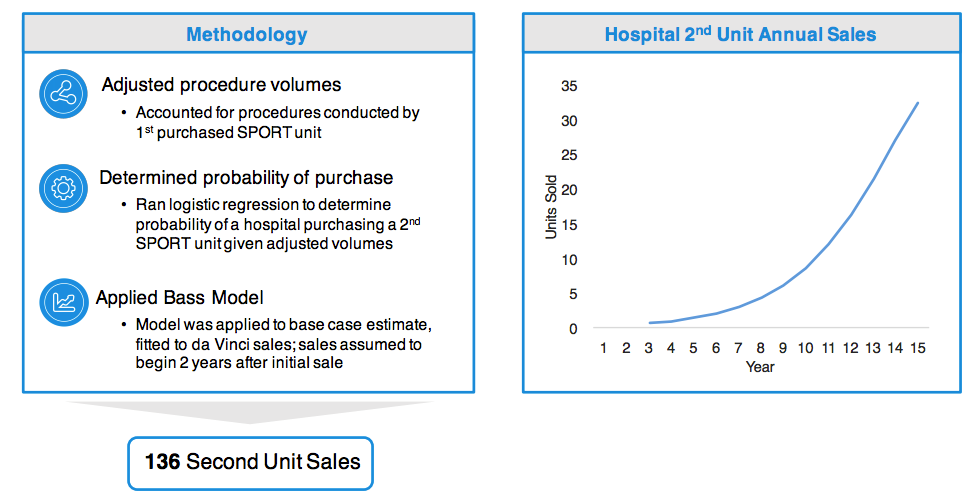

**Figure 7:** *Second Units Hospital Sales Results*

#### Replacement Sales

SPORT units have a useful life of approximately 5 years, which is the same as da Vinci. Thus, replacement sales also needed to be built into the projections. The 5-year lifespan was operationalized as 20% of the installed base being replaced every year, starting 5 years after the first sale. We also applied a 5% “churn rate” which reduced the number of replacement sales. This led to 444 replacement units sold within the 15-year timeline.

“Acquisition of a da Vinci Surgical System.” [Office of Health Care Access](http://www.ct.gov/dph/lib/dph/ohca/condecisions/03-30049dec.pdf)

Percent of machines that are at their end of useful lives, but will not be replaced.

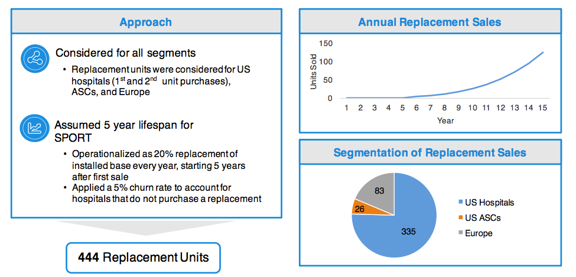

**Figure 8:** *Replacement Sales Results*

#### Total Results

Overall, our projections show that Titan can sell 1965 units within a 15-year timeframe. The following graph shows Titan’s year by year sales, broken down by sales channels.

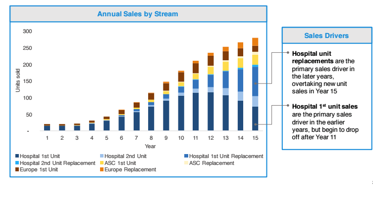

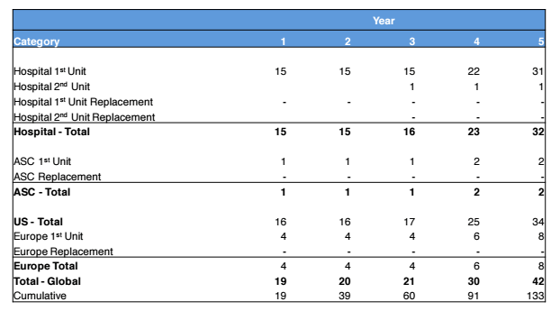

**Figure 9:** *Year by Year Sales Estimation*

We ran a sensitivity analysis on our 15 year cumulative sales figure. Titan’s sales estimates range from 1202 (most conservative) to 2237 (most optimistic).

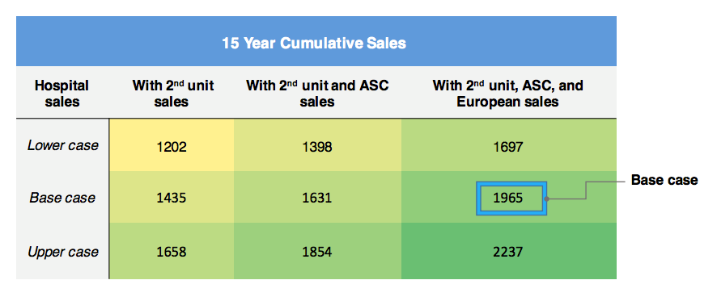

**Figure 10:** *Sensitivity Analysis*

## Limitations

As with any analysis, there are limitations. Given the depth and breadth of the analysis we have conducted here, there are certain approaches or assumptions that have weaknesses. We have tried to mitigate these weaknesses as much as possible. The following is a table listing what we consider our primary limitations in this analysis, and how we have mitigated the impact of these limitations.

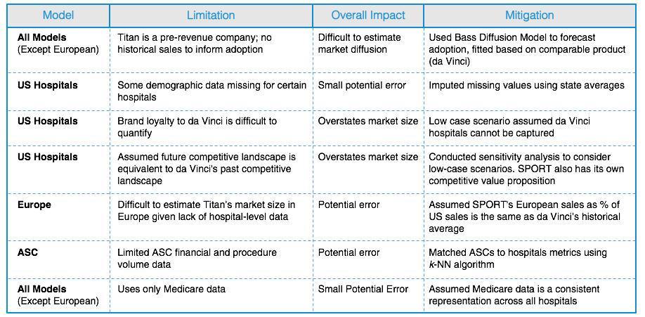

**Figure 11:** *Limitations and Mitigation*

## Analysis and Conclusion

We combined both analytical techniques and deep understanding of market conditions to project Titan’s market potential. Given the gap in the market for a low-cost MIS surgical robot, we believe that Titan can fulfill SPORT’s market potential. With unique features, focus on high-volume procedures, and portability, the SPORT surgical system is an attractive product for healthcare facilities that want to capitalize on the growing trend of medical robotics. Although a second mover, we believe the stage is set for Titan, given favorable market conditions. SPORT has a unique competitive advantage and will address healthcare facilities that have been untapped by da Vinci.

This analysis only focuses on the US and European market to be conservative. However, there will certainly be opportunities for SPORT in other countries, particularly as they establish a presence in this market. Furthermore, the analytical techniques, assumptions, and growth rates were made to be conservative to avoid any possible overestimation of the market. In creating projections for a pre-revenue company, we hope that these numbers can be used by investors to understand the market potential and value the company, or by Titan internally to understand their demand.

## Disclosure

*RNFC has conducted and written this analysis independently. The work was sponsored by Titan Medical Inc.*

*Many factors or related assumptions could cause the Company’s actual results, performance or achievements to be materially different from any future results, performance or achievements that may be expressed or implied within this presentation, including, without limitation, those risks and assumptions listed in the “Risk Factors” section of the Company’s Annual Information Form dated March 30, 2016 (which may be viewed at [www.sedar.com](http://www.sedar.com/)).*